# Coursera’s Regression Models Course - Course Project

Diogenes A. R. Justo

Sunday, November 23, 2014

Specific orientations: - The report must be written as a PDF output from r-markdown; - Two pages os less for main text. Figures can be used as appendix up to 5 pages; - First paragraph of executive summary.

## 1. Data exploration

First we take a look of data by head and summary commands.

```r
head(mtcars)
```

```
##                    mpg cyl disp  hp drat    wt  qsec vs am gear carb
## Mazda RX4         21.0   6  160 110 3.90 2.620 16.46  0  1    4    4
## Mazda RX4 Wag     21.0   6  160 110 3.90 2.875 17.02  0  1    4    4
## Datsun 710        22.8   4  108  93 3.85 2.320 18.61  1  1    4    1
## Hornet 4 Drive    21.4   6  258 110 3.08 3.215 19.44  1  0    3    1
## Hornet Sportabout 18.7   8  360 175 3.15 3.440 17.02  0  0    3    2
## Valiant           18.1   6  225 105 2.76 3.460 20.22  1  0    3    1
```

```r
summary(mtcars)
```

```
##       mpg            cyl            disp             hp
##  Min.   :10.4   Min.   :4.00   Min.   : 71.1   Min.   : 52.0
##  1st Qu.:15.4   1st Qu.:4.00   1st Qu.:120.8   1st Qu.: 96.5
##  Median :19.2   Median :6.00   Median :196.3   Median :123.0
##  Mean   :20.1   Mean   :6.19   Mean   :230.7   Mean   :146.7
##  3rd Qu.:22.8   3rd Qu.:8.00   3rd Qu.:326.0   3rd Qu.:180.0
##  Max.   :33.9   Max.   :8.00   Max.   :472.0   Max.   :335.0
##       drat            wt            qsec            vs
##  Min.   :2.76   Min.   :1.51   Min.   :14.5   Min.   :0.000
##  1st Qu.:3.08   1st Qu.:2.58   1st Qu.:16.9   1st Qu.:0.000
##  Median :3.69   Median :3.33   Median :17.7   Median :0.000
##  Mean   :3.60   Mean   :3.22   Mean   :17.8   Mean   :0.438
##  3rd Qu.:3.92   3rd Qu.:3.61   3rd Qu.:18.9   3rd Qu.:1.000
##  Max.   :4.93   Max.   :5.42   Max.   :22.9   Max.   :1.000
##        am             gear           carb
##  Min.   :0.000   Min.   :3.00   Min.   :1.00
##  1st Qu.:0.000   1st Qu.:3.00   1st Qu.:2.00
##  Median :0.000   Median :4.00   Median :2.00
##  Mean   :0.406   Mean   :3.69   Mean   :2.81
##  3rd Qu.:1.000   3rd Qu.:4.00   3rd Qu.:4.00
##  Max.   :1.000   Max.   :5.00   Max.   :8.00
```

From head results we can see that except by car names, all other data is numeric (that could be used in regression models). May be some numeric factors (like gear). Also, looking summary we can conclude that data is complete, with no NA’s, and for this reason data cleaning is not needed.

Another good visual exploration is done by using pairs command, with graphically comparision for each two variables.

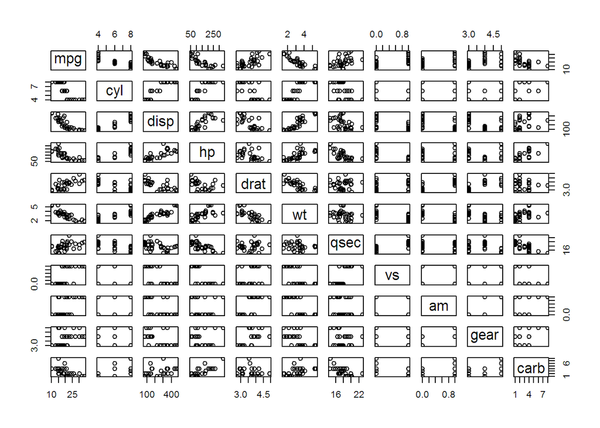

```r
print(pairs(mtcars))
```

Visually we observe that cyl, disp, hp, drat and wt have some correlation with MPG.

## 2. Models analyses

By the way, using visual insight, we will take first models using that fields.

```r
m1 <- lm(mpg ~ cyl+disp+hp+drat+wt, data=mtcars)
summary(m1)
```

```
##
## Call:
## lm(formula = mpg ~ cyl + disp + hp + drat + wt, data = mtcars)
##
## Residuals:
##    Min     1Q Median     3Q    Max
## -3.701 -1.685 -0.423  1.168  5.726
##
## Coefficients:
##             Estimate Std. Error t value Pr(>|t|)
## (Intercept)  36.0084     7.5714    4.76  6.4e-05 ***
## cyl          -1.1075     0.7159   -1.55   0.1339
## disp          0.0124     0.0119    1.04   0.3085
## hp           -0.0240     0.0133   -1.81   0.0821 .
## drat          0.9522     1.3908    0.68   0.4996
## wt           -3.6733     1.0590   -3.47   0.0018 **
## ---
## Signif. codes:  0 '***' 0.001 '**' 0.01 '*' 0.05 '.' 0.1 ' ' 1
##
## Residual standard error: 2.54 on 26 degrees of freedom
## Multiple R-squared:  0.851,  Adjusted R-squared:  0.823
## F-statistic: 29.8 on 5 and 26 DF,  p-value: 5.62e-10
```

Multiple R-squared for this model is in good shape: 0.8513, with p-value very low. So, we started with good results.

Another try could be include gear like predictor. Let see:

```r
m2 <- lm(mpg ~ cyl+disp+hp+drat+wt+gear, data=mtcars)
summary(m2)
```

```
##
## Call:
## lm(formula = mpg ~ cyl + disp + hp + drat + wt + gear, data = mtcars)
##
## Residuals:
##    Min     1Q Median     3Q    Max
## -3.192 -1.604 -0.433  1.179  5.834
##
## Coefficients:
##             Estimate Std. Error t value Pr(>|t|)
## (Intercept)  34.7214     8.2495    4.21  0.00029 ***
## cyl          -1.0284     0.7500   -1.37  0.18249
## disp          0.0137     0.0125    1.10  0.28215
## hp           -0.0284     0.0169   -1.68  0.10511
## drat          0.7156     1.5155    0.47  0.64088
## wt           -3.6181     1.0835   -3.34  0.00264 **
## gear          0.4866     1.1265    0.43  0.66948
## ---
## Signif. codes:  0 '***' 0.001 '**' 0.01 '*' 0.05 '.' 0.1 ' ' 1
##
## Residual standard error: 2.58 on 25 degrees of freedom
## Multiple R-squared:  0.852,  Adjusted R-squared:  0.817
## F-statistic: 24.1 on 6 and 25 DF,  p-value: 2.99e-09
```

Multiple R-squared for this model is more than first on: 0.8524, with p-value very low. We reached a little bit better model.

Automatic transmission is well knew to take more gas consume. Let see what if we include more this predictor.

```r
m3 <- lm(mpg ~ cyl+disp+hp+drat+wt+gear+am, data=mtcars)
summary(m3)
```

```
##
## Call:
## lm(formula = mpg ~ cyl + disp + hp + drat + wt + gear + am, data = mtcars)
##
## Residuals:
##    Min     1Q Median     3Q    Max
## -3.425 -1.575 -0.683  1.308  5.562
##
## Coefficients:
##             Estimate Std. Error t value Pr(>|t|)
## (Intercept)  35.9541     8.4867    4.24  0.00029 ***
## cyl          -1.0288     0.7568   -1.36  0.18664
## disp          0.0127     0.0127    1.00  0.32874
## hp           -0.0291     0.0171   -1.70  0.10113
## drat          0.4765     1.5625    0.30  0.76303
## wt           -3.2775     1.1850   -2.77  0.01075 *
## gear          0.0358     1.2876    0.03  0.97807
## am            1.3514     1.8137    0.75  0.46344
## ---
## Signif. codes:  0 '***' 0.001 '**' 0.01 '*' 0.05 '.' 0.1 ' ' 1
##
## Residual standard error: 2.6 on 24 degrees of freedom
## Multiple R-squared:  0.856,  Adjusted R-squared:  0.814
## F-statistic: 20.3 on 7 and 24 DF,  p-value: 1.19e-08
```

Again we improved the model: multiple R-squared for this model: 0.8558, still p-value very low.

And… what about include all variables to predict?

```r
m4 <- lm(mpg ~ ., data=mtcars)
summary(m4)
```

```
##
## Call:
## lm(formula = mpg ~ ., data = mtcars)
##
## Residuals:
##    Min     1Q Median     3Q    Max
##  -3.45  -1.60  -0.12   1.22   4.63
##
## Coefficients:
##             Estimate Std. Error t value Pr(>|t|)
## (Intercept)  12.3034    18.7179    0.66    0.518
## cyl          -0.1114     1.0450   -0.11    0.916
## disp          0.0133     0.0179    0.75    0.463
## hp           -0.0215     0.0218   -0.99    0.335
## drat          0.7871     1.6354    0.48    0.635
## wt           -3.7153     1.8944   -1.96    0.063 .
## qsec          0.8210     0.7308    1.12    0.274
## vs            0.3178     2.1045    0.15    0.881
## am            2.5202     2.0567    1.23    0.234
## gear          0.6554     1.4933    0.44    0.665
## carb         -0.1994     0.8288   -0.24    0.812
## ---
## Signif. codes:  0 '***' 0.001 '**' 0.01 '*' 0.05 '.' 0.1 ' ' 1
##
## Residual standard error: 2.65 on 21 degrees of freedom
## Multiple R-squared:  0.869,  Adjusted R-squared:  0.807
## F-statistic: 13.9 on 10 and 21 DF,  p-value: 3.79e-07
```

This is the better model: multiple R-squared reached 0.869.

## 3. Model Improve

First one, we will take a look of residuals.

### 3.1 Residual analyses

Plotting residuals is a good tool to verify distances from real point, and predict point.

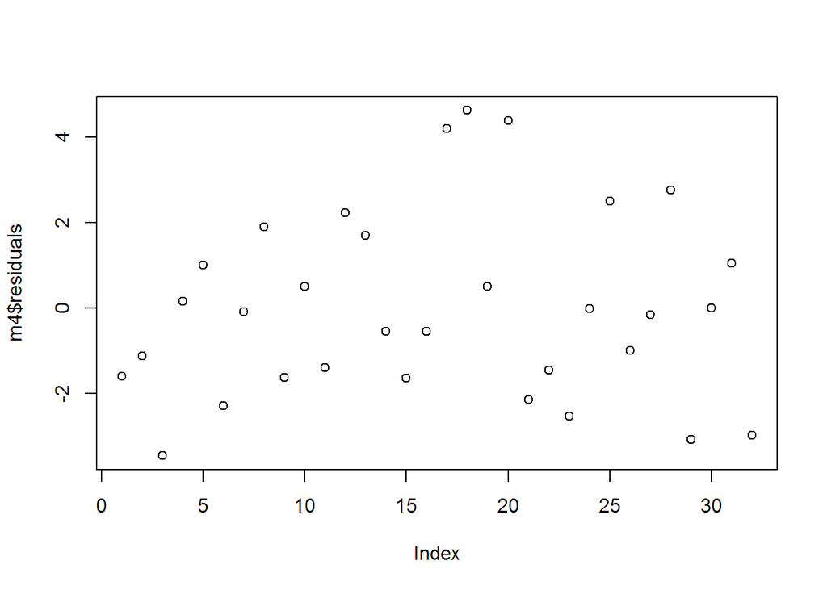

```r
print(plot(m4$residuals))
```

```r
ol <- rep(0,32)
ol[17]<-ol[18]<-ol[20]<-1
mtcars2 <- cbind(mtcars,ol)
m5 <- lm(mpg ~ ., data=mtcars2)
summary(m5)
```

```
##
## Call:
## lm(formula = mpg ~ ., data = mtcars2)
##
## Residuals:
##    Min     1Q Median     3Q    Max
## -2.546 -1.006  0.022  0.803  3.107
##
## Coefficients:
##             Estimate Std. Error t value Pr(>|t|)
## (Intercept)  26.7796    12.7249    2.10  0.04818 *
## cyl          -0.4611     0.6968   -0.66  0.51572
## disp          0.0207     0.0119    1.73  0.09848 .
## hp           -0.0329     0.0146   -2.25  0.03553 *
## drat         -0.2133     1.1020   -0.19  0.84847
## wt           -5.1804     1.2879   -4.02  0.00067 ***
## qsec          0.4212     0.4910    0.86  0.40120
## vs            0.1590     1.3972    0.11  0.91050
## am           -0.4371     1.4763   -0.30  0.77023
## gear          1.2639     0.9979    1.27  0.21985
## carb          0.3488     0.5599    0.62  0.54030
## ol            6.4753     1.2310    5.26  3.8e-05 ***
## ---
## Signif. codes:  0 '***' 0.001 '**' 0.01 '*' 0.05 '.' 0.1 ' ' 1
##
## Residual standard error: 1.76 on 20 degrees of freedom
## Multiple R-squared:  0.945,  Adjusted R-squared:  0.915
## F-statistic: 31.3 on 11 and 20 DF,  p-value: 3.52e-10
```

Gotcha! (R-multiple squared=0.945)

### 4. Conclusions

Of course that a regression model analysis take a look from data. Some results can be biased by quantity of observations. This is not a representation of some population of cars, just a view of some comparision of some cars.